# Multisample Hypotheses

2026-02-03

H0: µ1=µ2=µ3

# One-way ANOVA

```r
# set up the data
sold <- c(40,30,11,22,55,34,75,40,51,72,12,2,32,5,14)
type <- c("meatball", "blt", "italian")
rep <- c(5,5,5)
sandwhich = rep(type, rep)

sand.data <- data.frame(sandwhich, sold)

# two ways to do it
mod1 <- lm(sold~sandwhich, data = sand.data)
mod2 <- aov(sold ~ sandwhich, data = sand.data)
```

## Data must then be extracted from the model

```r
anova(mod1) # produces the ANOVA table
```

```
## Analysis of Variance Table
##
## Response: sold
##           Df Sum Sq Mean Sq F value   Pr(>F)
## sandwhich  2 4299.6 2149.80   8.446 0.005134 **
## Residuals 12 3054.4  254.53
## ---
## Signif. codes:  0 '***' 0.001 '**' 0.01 '*' 0.05 '.' 0.1 ' ' 1
```

## ANOVA Assumptions

1. observations/samples are independent of each other
2. Error/residuals of the data are normally distributed
3. Homogeneity of variance

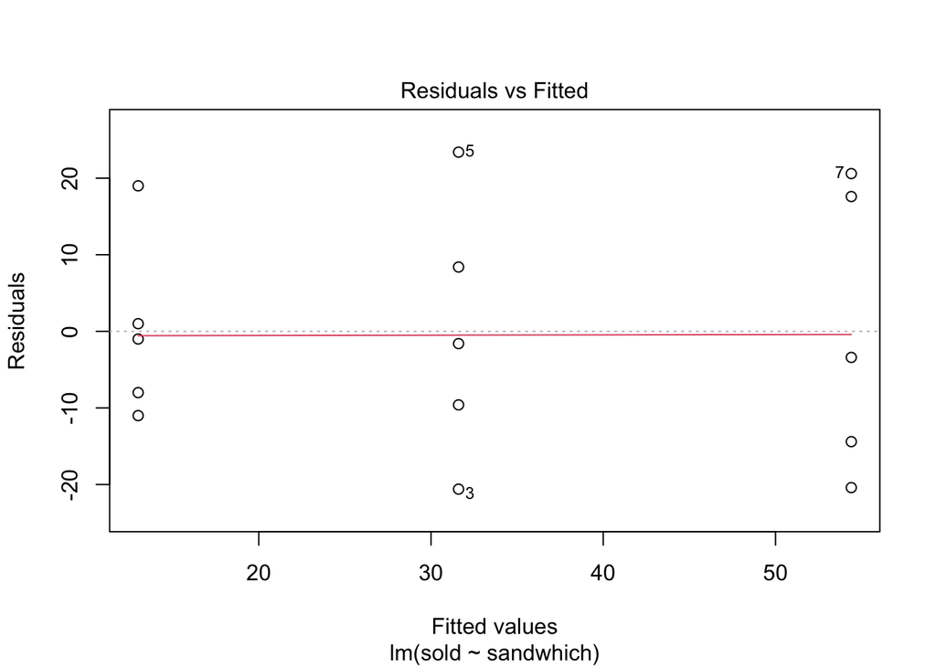

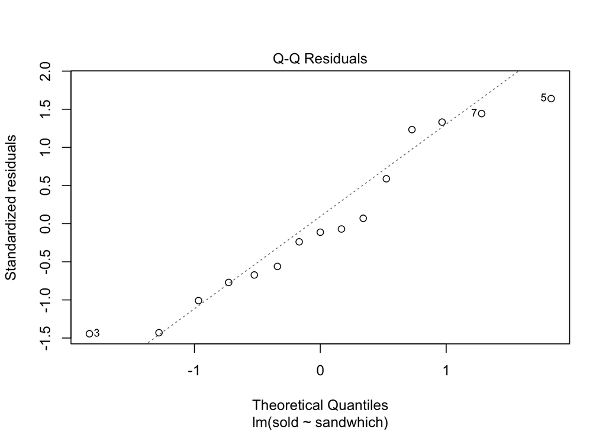

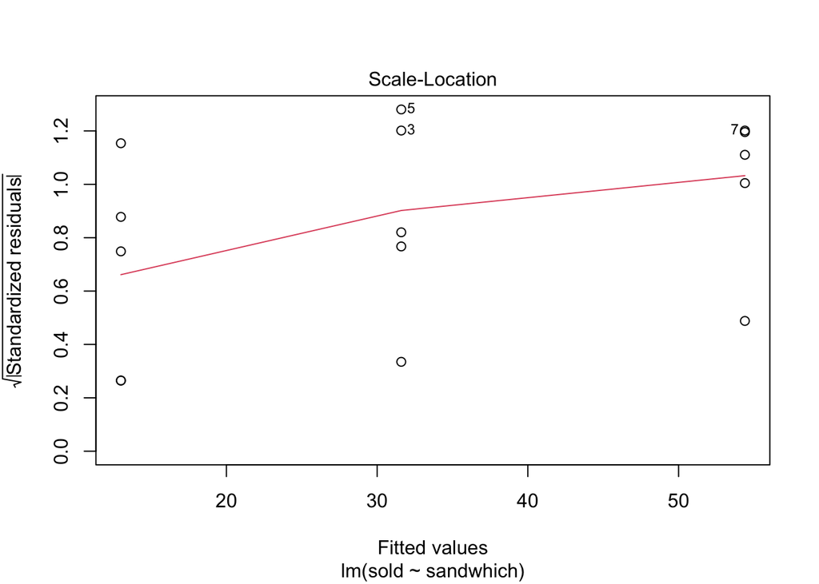

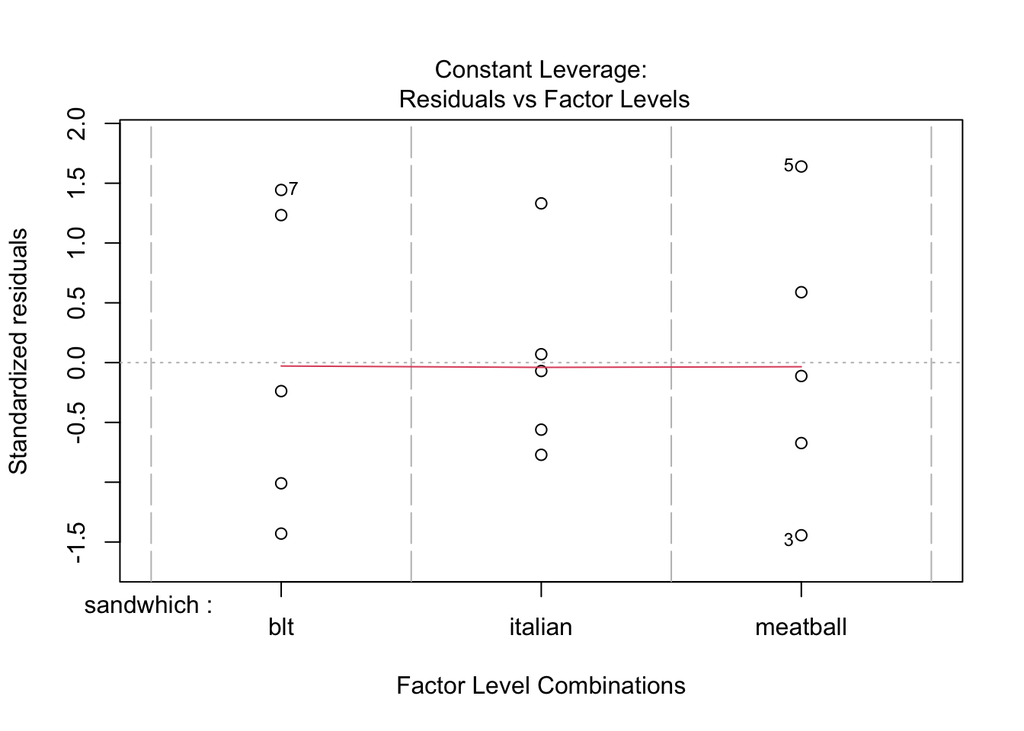

```r
plot(mod1) #produces plots for residuals and normal quantiles
```

# Post-hoc tests

Tukey’s HSD and Student-Newman Keuls tests are the most frequently used.

These tests have the same assumptions as an ANOVA.

Automatically correct for family-wise error on multiple comparisons of the same data.

```r
TukeyHSD(mod2) # requires 'aov()' type model
```

```
##   Tukey multiple comparisons of means
##     95% family-wise confidence level
##
## Fit: aov(formula = sold ~ sandwhich, data = sand.data)
##
## $sandwhich
##                   diff        lwr        upr     p adj
## italian-blt      -41.4 -68.319436 -14.480564 0.0038654
## meatball-blt     -22.8 -49.719436   4.119436 0.1009999
## meatball-italian  18.6  -8.319436  45.519436 0.1975729
```

SNK is less conservative, and requires the ‘agricolae’ package. SNK is more likely to find significant differences.

```r
library(agricolae)


#must define which variable to use
print(SNK.test(mod2, "sandwhich", group = F))
```

```
## $statistics
##    MSerror Df Mean       CV
##   254.5333 12   33 48.34576
##
## $parameters
##   test    name.t ntr alpha
##    SNK sandwhich   3  0.05
##
## $snk
##      Table CriticalRange
## 2 3.081307      21.98479
## 3 3.772929      26.91944
##
## $means
##          sold      std r       se Min Max Q25 Q50 Q75
## blt      54.4 18.50135 5 7.134891  34  75  40  51  72
## italian  13.0 11.70470 5 7.134891   2  32   5  12  14
## meatball 31.6 16.86120 5 7.134891  11  55  22  30  40
##
## $comparison
##                    difference pvalue signif.         LCL       UCL
## blt - italian            41.4 0.0039      **  14.4805639 68.319436
## blt - meatball           22.8 0.0432       *   0.8152137 44.784786
## italian - meatball      -18.6 0.0901       . -40.5847863  3.384786
##
## $groups
## NULL
##
## attr(,"class")
## [1] "group"
```

```r
#pull just comparisons with
print(SNK.test(mod2, "sandwhich", group = F))[["comparison"]]
```

```
## $statistics
##    MSerror Df Mean       CV
##   254.5333 12   33 48.34576
##
## $parameters
##   test    name.t ntr alpha
##    SNK sandwhich   3  0.05
##
## $snk
##      Table CriticalRange
## 2 3.081307      21.98479
## 3 3.772929      26.91944
##
## $means
##          sold      std r       se Min Max Q25 Q50 Q75
## blt      54.4 18.50135 5 7.134891  34  75  40  51  72
## italian  13.0 11.70470 5 7.134891   2  32   5  12  14
## meatball 31.6 16.86120 5 7.134891  11  55  22  30  40
##
## $comparison
##                    difference pvalue signif.         LCL       UCL
## blt - italian            41.4 0.0039      **  14.4805639 68.319436
## blt - meatball           22.8 0.0432       *   0.8152137 44.784786
## italian - meatball      -18.6 0.0901       . -40.5847863  3.384786
##
## $groups
## NULL
##
## attr(,"class")
## [1] "group"
```

```
##                    difference pvalue signif.         LCL       UCL
## blt - italian            41.4 0.0039      **  14.4805639 68.319436
## blt - meatball           22.8 0.0432       *   0.8152137 44.784786
## italian - meatball      -18.6 0.0901       . -40.5847863  3.384786
```

# Tests of Difference vs. Tests of Relationships

Tests of Difference: - Is this group different from that one? (t-test, ANOVA’s)

Tests of Relationship: - Does this change with that? (caused or correlated?)

# Simple Linear Correlation

Three questions: 1. Are two measurement variables related in a linear fashion? 2. If they are, positively or negatively? 3. How strongly?

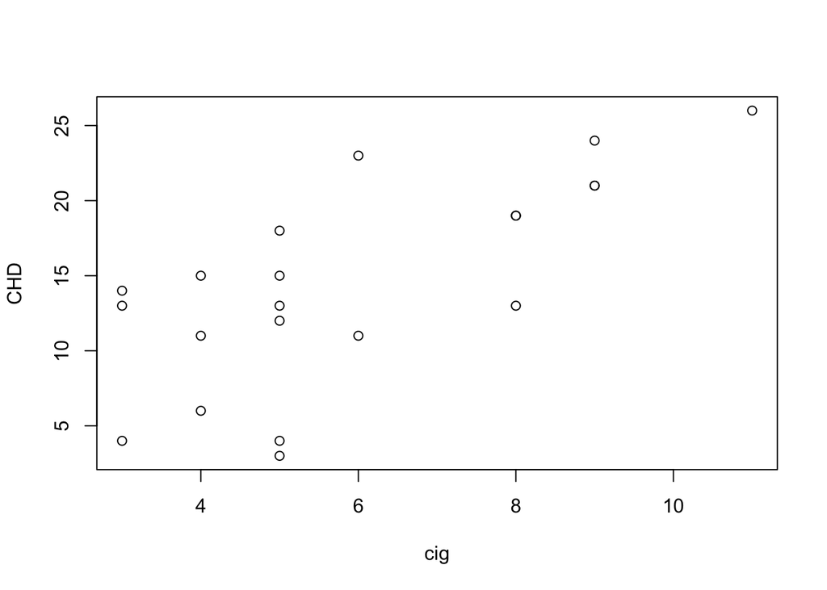

```r
cig <- c(11,9,9,9,8,8,8,6,6,5,5,5,5,5,5,4,4,4,3,3,3)
CHD <- c(26,21,24,21,19,13,19,11,23,15,13,4,18,12,3,11,15,6,13,4,14)

plot(cig, CHD)
```

```r
cor(cig,CHD) # (just) calculates the correlation coefficient
```

```
## [1] 0.7125065
```

```r
library(Hmisc)
data <- cbind(cig, CHD)
rcorr(data, type = "pearson") # provides r, n, and p
```

```
##      cig  CHD
## cig 1.00 0.71
## CHD 0.71 1.00
##
## n= 21
##
##
## P
##     cig   CHD
## cig       3e-04
## CHD 3e-04
```

## The limitations of Correlation

Does not say anything about causality. This requires regression.

# Linear Regression

First we plot the points in a scatterplot, just like with correlation.

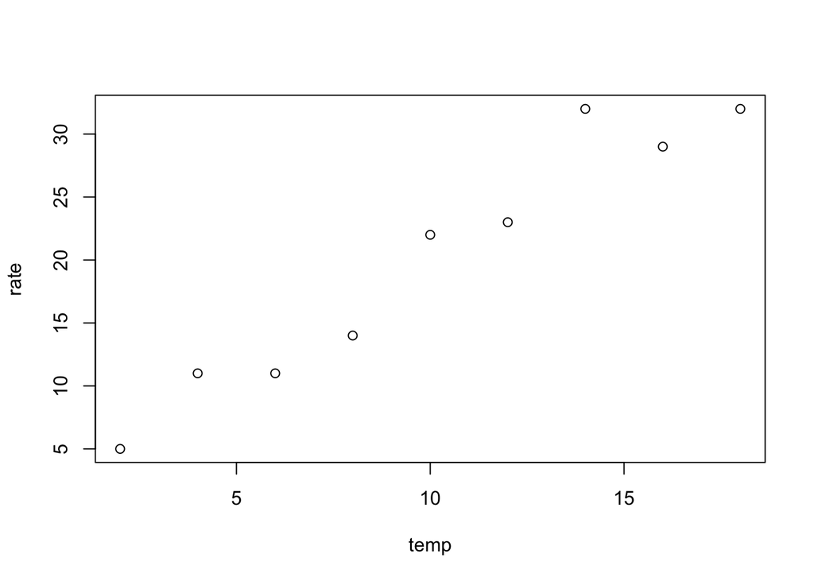

```r
temp <- seq(2,18,2)
rate = c(5,11,11,14,22,23,32,29,32)
plot(temp, rate)
```

```r
reg.mod <- lm(rate ~ temp)
summary(reg.mod)
```

```
##
## Call:
## lm(formula = rate ~ temp)
##
## Residuals:
##     Min      1Q  Median      3Q     Max
## -2.3389 -1.7889 -0.6889  1.7611  5.0111
##
## Coefficients:
##             Estimate Std. Error t value Pr(>|t|)
## (Intercept)   2.1389     1.9170   1.116    0.301
## temp          1.7750     0.1703  10.421 1.63e-05 ***
## ---
## Signif. codes:  0 '***' 0.001 '**' 0.01 '*' 0.05 '.' 0.1 ' ' 1
##
## Residual standard error: 2.639 on 7 degrees of freedom
## Multiple R-squared:  0.9394, Adjusted R-squared:  0.9308
## F-statistic: 108.6 on 1 and 7 DF,  p-value: 1.629e-05
```

Model summary reports multiple statistics associated with the regression. There are two r-squared values, always report the *adjusted* R-squared to avoid artificial inflation by adding variables.

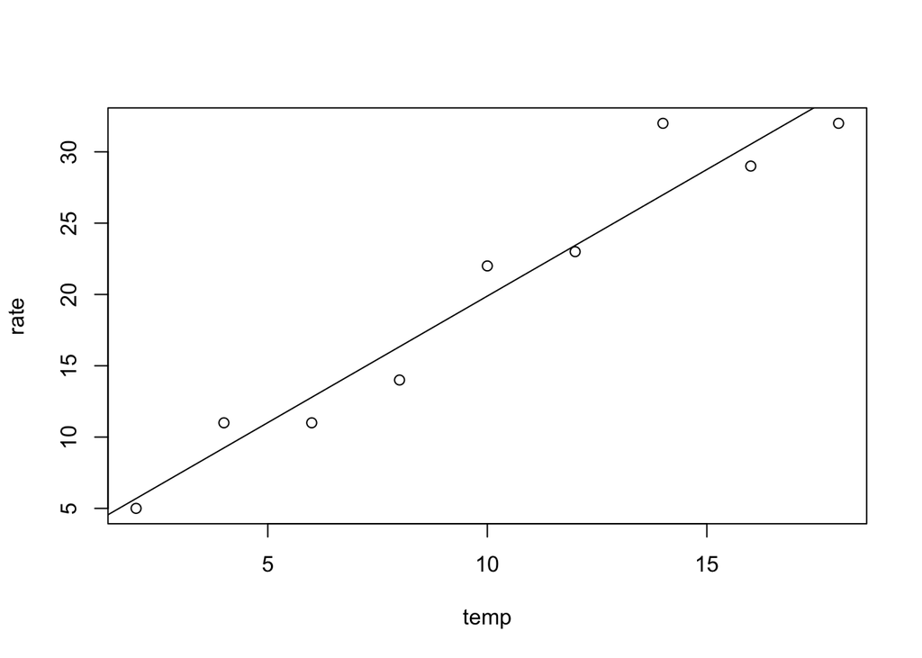

```r
plot(temp, rate)
abline(reg.mod) ## plug in regression model
```

# Factorial ANOVA

Considers the effects of more than one independent variable on a dependendent variable *simultaneously*

The *interaction effect* is how the two independent variables simultaneously alter the dependent variable.

```r
lard = c("fresh","rancid")
rep = c(6,6)
treatment = rep(lard, rep)

gender = c("M","F","M","F")
rep = c(3,3,3,3)
sex = rep(gender, rep)

cons = c(709,679,699,657,594,677,592,538,476,508,505,539)

data = data.frame(treatment, sex, cons)
```

To run the ANOVA is simple, just MUST include the interaction effect.

```r
mod1 <- aov(cons ~ sex + treatment + sex*treatment, data = data)
anova(mod1)
```

```
## Analysis of Variance Table
##
## Response: cons
##               Df Sum Sq Mean Sq F value    Pr(>F)
## sex            1   3781    3781  2.5925 0.1460358
## treatment      1  61204   61204 41.9685 0.0001925 ***
## sex:treatment  1    919     919  0.6300 0.4502546
## Residuals      8  11667    1458
## ---
## Signif. codes:  0 '***' 0.001 '**' 0.01 '*' 0.05 '.' 0.1 ' ' 1
```

Including just the interaction will include all factors in the model by default, so the code above can be shorthanded:

```r
mod1 <- aov(cons ~ sex*treatment, data = data)
anova(mod1)
```

```
## Analysis of Variance Table
##
## Response: cons
##               Df Sum Sq Mean Sq F value    Pr(>F)
## sex            1   3781    3781  2.5925 0.1460358
## treatment      1  61204   61204 41.9685 0.0001925 ***
## sex:treatment  1    919     919  0.6300 0.4502546
## Residuals      8  11667    1458
## ---
## Signif. codes:  0 '***' 0.001 '**' 0.01 '*' 0.05 '.' 0.1 ' ' 1
```

Now to visualize the results, we can use an interaction plot:

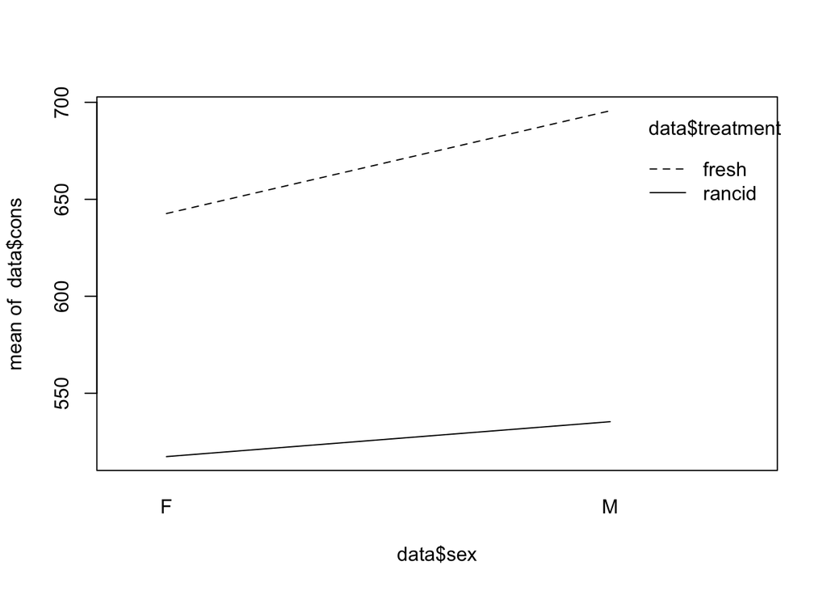

```r
interaction.plot(data$sex, data$treatment, data$cons)
```

Visualizing with ggplot for better graphics, we can customize each factor if desired.

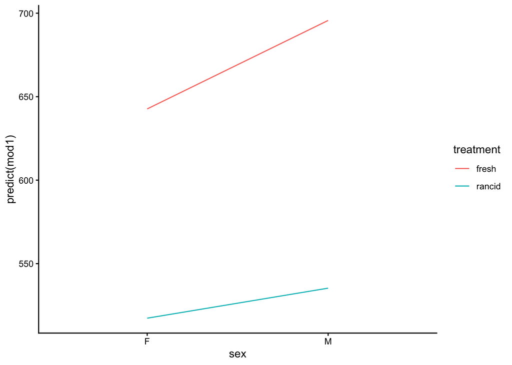

```r
library(ggplot2)
ggplot(data, aes(x = sex, y = predict(mod1), group = treatment,
                 color = treatment)) + geom_line() + theme_classic()
```

## Multi-way ANOVA for unbalanced designs

Type I, II, and III ANOVA models calculate the sums of squares differently based on the underlying assumptions.

Because SS are calculated sequentially, different results will arise depending on the order of the factors in the model (for unbalanced data).

Not ideal because it is testing the effect of the first factor without consideration of the second factor.

### Type II: “Progressive SS”

Tests for each main effect *after* the other main effect is considered. But, assumes that there is *NO* significant interaction.

Therefore, Type II should only be used after a potential interaction has been proven *not significant*.

This model has the most power when the interaction is not significant.

Does not calculate the intercept.

### Type III

Order independent.

Tests the main effect after other main effects AND the interaction effects.

Valid when significant interactions are present.

```r
# load in the data
lizard1 = read.csv("lizard_dispersal.csv")

# model one
liz.mod1 <- aov(disp_avg ~ treatment + island + treatment*island, data = lizard1)

# reverse the order (for demonstration)
liz.mod2 <- aov(disp_avg ~ island + treatment + island:treatment, data = lizard1)

anova(liz.mod1)
```

```
## Analysis of Variance Table
##
## Response: disp_avg
##                  Df Sum Sq Mean Sq F value  Pr(>F)
## treatment         1   1229 1229.14  2.2593 0.13738
## island            1   3145 3144.86  5.7807 0.01889 *
## treatment:island  1      8    7.52  0.0138 0.90673
## Residuals        69  37538  544.03
## ---
## Signif. codes:  0 '***' 0.001 '**' 0.01 '*' 0.05 '.' 0.1 ' ' 1
```

```r
anova(liz.mod2)
```

```
## Analysis of Variance Table
##
## Response: disp_avg
##                  Df Sum Sq Mean Sq F value  Pr(>F)
## island            1   3572  3572.1  6.5660 0.01258 *
## treatment         1    802   801.9  1.4739 0.22886
## island:treatment  1      8     7.5  0.0138 0.90673
## Residuals        69  37538   544.0
## ---
## Signif. codes:  0 '***' 0.001 '**' 0.01 '*' 0.05 '.' 0.1 ' ' 1
```

Notice that the p-values and other parameters for the main factors are different between the two models, while the interaction effect parameters remained the same (because it is the last to be calculated).

This is because R is caluclating SS with Type I (sequential sums of squares).

```r
# load in the datat
lizard2 <- read.csv("lizard_dispersal2.csv")

liz.mod3 <- aov(disp_avg ~ treatment + island + treatment*island, data = lizard2)

anova(liz.mod3) ## uses sequential sums of squares
```

```
## Analysis of Variance Table
##
## Response: disp_avg
##                  Df Sum Sq Mean Sq F value  Pr(>F)
## treatment         1   1223 1222.69  2.4048 0.12554
## island            1   2256 2255.78  4.4366 0.03881 *
## treatment:island  1   2807 2806.63  5.5201 0.02167 *
## Residuals        69  35083  508.44
## ---
## Signif. codes:  0 '***' 0.001 '**' 0.01 '*' 0.05 '.' 0.1 ' ' 1
```

Our interaction is significant, so we shouldn’t use Type I. We *must* use Type III sums of squares. This requires the ‘car’ package.

```r
library(car)
# set up the contrasts to change how SS is calculated to Type III.
options(contrasts = c("contr.sum", "contr.poly"))

## always include this option/contrasts code with the car package.

# use 'Anova()' in car, to evaluate model 'lm()' using Type III
Anova(lm(disp_avg~treatment * island, data = lizard2), type = 3)
```

```
## Anova Table (Type III tests)
##
## Response: disp_avg
##                  Sum Sq Df F value  Pr(>F)
## (Intercept)        1673  1  3.2909 0.07401 .
## treatment           985  1  1.9367 0.16849
## island             3066  1  6.0305 0.01658 *
## treatment:island   2807  1  5.5201 0.02167 *
## Residuals         35083 69
## ---
## Signif. codes:  0 '***' 0.001 '**' 0.01 '*' 0.05 '.' 0.1 ' ' 1
```

# Analysis of Co-Variance

To test for differences between group means when there exists an extraneous continous variable that affects the continuous *response* variable.

Advantages: -reduces error variance by explaining some variation -greater experimental control provides better insight into response

Assumptions: -same as ANOVA plus… 1. Independence of the covariate and factor 2. Homogeneity of regression slopes –> covariate should explain the factors equally –> the interaction should *NOT* be significant

In R, achieved with a Type III SS ANOVA, first testing the interaction effect for significance.

```r
data <- read.csv("snakes_ANCOVA.csv")

# Step 1: Test for homogeneity of slopes
library(car)
mod1 <- lm(skull~svl + sex + svl:sex, data = data)
Anova(mod1, type = 3)
```

```
## Anova Table (Type III tests)
##
## Response: skull
##             Sum Sq  Df  F value    Pr(>F)
## (Intercept) 1252.0   1 144.2501 < 2.2e-16 ***
## svl         4785.2   1 551.3179 < 2.2e-16 ***
## sex           50.9   1   5.8666   0.01622 *
## svl:sex      197.5   1  22.7588 3.294e-06 ***
## Residuals   1961.6 226
## ---
## Signif. codes:  0 '***' 0.001 '**' 0.01 '*' 0.05 '.' 0.1 ' ' 1
```

Can still evaluate the model through plots:

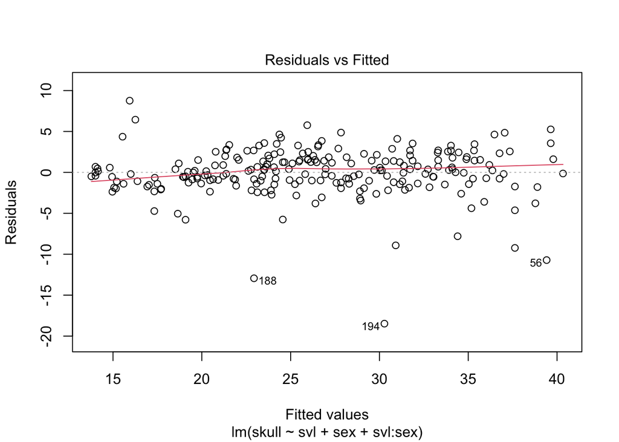

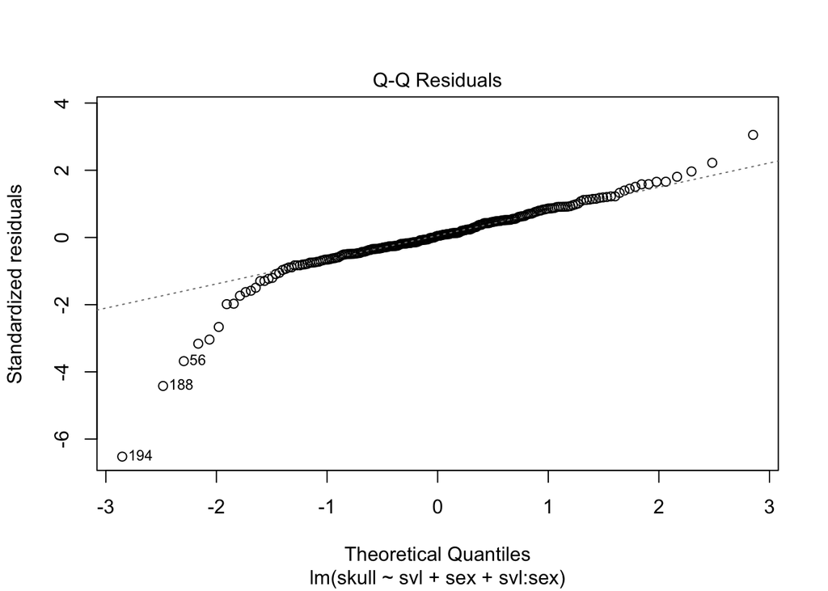

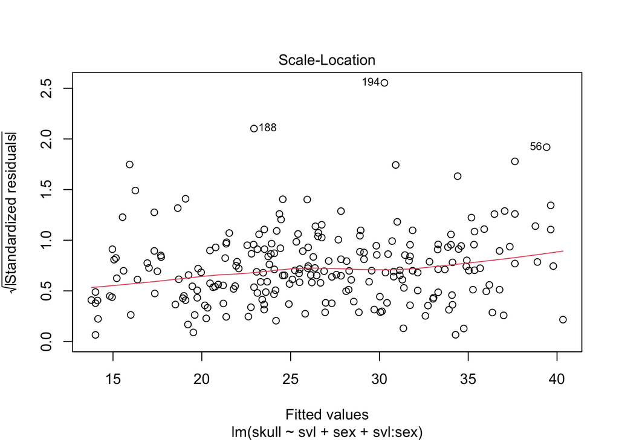

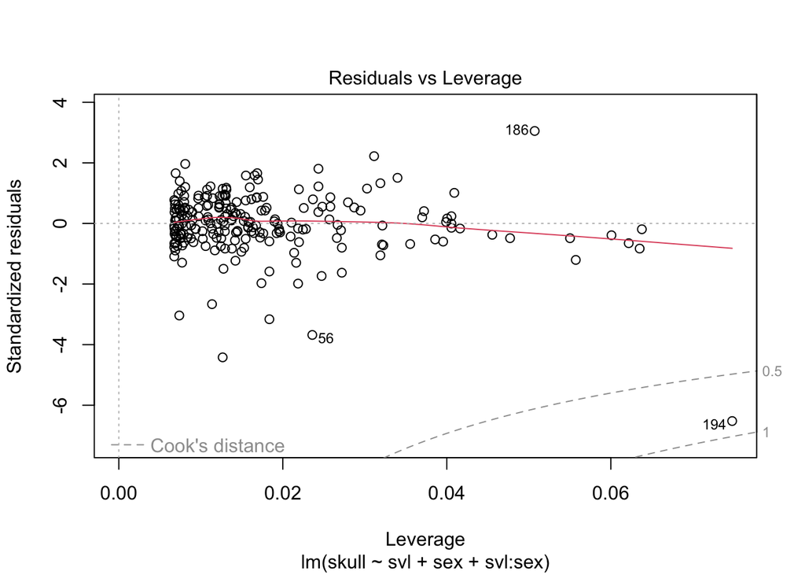

```r
plot(mod1)
```

Lets retry the ANCOVA with a different co-variate:

```r
mod2 <- lm(skull ~ svl + site + svl:site, data = data)
Anova(mod2, type = 3)
```

```
## Anova Table (Type III tests)
##
## Response: skull
##             Sum Sq  Df  F value    Pr(>F)
## (Intercept)  516.5   1  46.2031 9.705e-11 ***
## svl         8078.2   1 722.6897 < 2.2e-16 ***
## site          17.5   3   0.5211    0.6682
## svl:site      23.0   3   0.6855    0.5617
## Residuals   2481.5 222
## ---
## Signif. codes:  0 '***' 0.001 '**' 0.01 '*' 0.05 '.' 0.1 ' ' 1
```

No we do not have a significant interaction term, and can wrightfully continue with the ANCOVA.

To do this, we run a Type III model *without* the interaction, to force the model to assume even slopes.

```r
mod3 <- lm(skull ~ svl + site, data = data)

Anova(mod3, type = 3)
```

```
## Anova Table (Type III tests)
##
## Response: skull
##             Sum Sq  Df  F value    Pr(>F)
## (Intercept)  704.5   1  63.2936 8.653e-14 ***
## svl         9181.0   1 824.8079 < 2.2e-16 ***
## site          96.7   3   2.8966   0.03599 *
## Residuals   2504.5 225
## ---
## Signif. codes:  0 '***' 0.001 '**' 0.01 '*' 0.05 '.' 0.1 ' ' 1
```

# Multiple Regression

What is the relative contriubtion of multiple independent continuous variables to a single dependent continuous variable.

Allows us to tease apart hte variables having the *greatest* effect on a response variable when multiple variables are correlated with this response variable.

We can get a “purer” form of the relationship between a response variable and predictors.

We want to come up with the most parsimonious model with the fewest variables that actively predict variation in the response.

```r
state.x77
```

[output not shown]

[output cut: 47 more lines]

[output not shown]

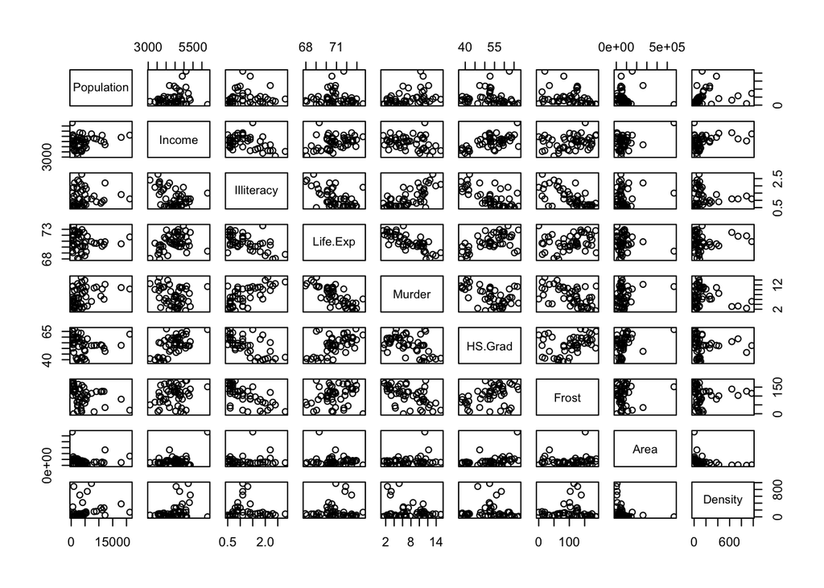

```r
st = data.frame(state.x77)
st$Density = st$Population*1000/st$Area

pairs(st) # provides a graphical correlation matrix of pairwise correlations
```

```r
# We will examine what variables significantly predict variation in life expectancy.
## run model as normal
model1 = lm(Life.Exp ~ Population + Income + Illiteracy + Murder + HS.Grad + Frost + Area + Density, data = st)

summary(model1)
```

```
##
## Call:
## lm(formula = Life.Exp ~ Population + Income + Illiteracy + Murder +
##     HS.Grad + Frost + Area + Density, data = st)
##
## Residuals:
##      Min       1Q   Median       3Q      Max
## -1.47514 -0.45887 -0.06352  0.59362  1.21823
##
## Coefficients:
##               Estimate Std. Error t value Pr(>|t|)
## (Intercept)  6.995e+01  1.843e+00  37.956  < 2e-16 ***
## Population   6.480e-05  3.001e-05   2.159   0.0367 *
## Income       2.701e-04  3.087e-04   0.875   0.3867
## Illiteracy   3.029e-01  4.024e-01   0.753   0.4559
## Murder      -3.286e-01  4.941e-02  -6.652 5.12e-08 ***
## HS.Grad      4.291e-02  2.332e-02   1.840   0.0730 .
## Frost       -4.580e-03  3.189e-03  -1.436   0.1585
## Area        -1.558e-06  1.914e-06  -0.814   0.4205
## Density     -1.105e-03  7.312e-04  -1.511   0.1385
## ---
## Signif. codes:  0 '***' 0.001 '**' 0.01 '*' 0.05 '.' 0.1 ' ' 1
##
## Residual standard error: 0.7337 on 41 degrees of freedom
## Multiple R-squared:  0.7501, Adjusted R-squared:  0.7013
## F-statistic: 15.38 on 8 and 41 DF,  p-value: 3.787e-10
```

```
##
## Call:
## lm(formula = Life.Exp ~ Population + Income + Murder + HS.Grad +
##     Frost + Area + Density, data = st)
##
## Residuals:
##      Min       1Q   Median       3Q      Max
## -1.47618 -0.38592 -0.05728  0.58817  1.42334
##
## Coefficients:
##               Estimate Std. Error t value Pr(>|t|)
## (Intercept)  7.098e+01  1.228e+00  57.825  < 2e-16 ***
## Population   5.675e-05  2.789e-05   2.034   0.0483 *
## Income       1.901e-04  2.883e-04   0.659   0.5133
## Murder      -3.122e-01  4.409e-02  -7.081 1.11e-08 ***
## HS.Grad      3.652e-02  2.161e-02   1.690   0.0984 .
## Frost       -6.059e-03  2.499e-03  -2.425   0.0197 *
## Area        -8.638e-07  1.669e-06  -0.518   0.6075
## Density     -8.612e-04  6.523e-04  -1.320   0.1939
## ---
## Signif. codes:  0 '***' 0.001 '**' 0.01 '*' 0.05 '.' 0.1 ' ' 1
##
## Residual standard error: 0.7299 on 42 degrees of freedom
## Multiple R-squared:  0.7466, Adjusted R-squared:  0.7044
## F-statistic: 17.68 on 7 and 42 DF,  p-value: 1.12e-10
```

```
##
## Call:
## lm(formula = Life.Exp ~ Population + Income + Murder + HS.Grad +
##     Frost + Density, data = st)
##
## Residuals:
##      Min       1Q   Median       3Q      Max
## -1.49555 -0.41246 -0.05336  0.58399  1.50535
##
## Coefficients:
##               Estimate Std. Error t value Pr(>|t|)
## (Intercept)  7.131e+01  1.042e+00  68.420  < 2e-16 ***
## Population   5.811e-05  2.753e-05   2.110   0.0407 *
## Income       1.324e-04  2.636e-04   0.502   0.6181
## Murder      -3.208e-01  4.054e-02  -7.912 6.32e-10 ***
## HS.Grad      3.499e-02  2.122e-02   1.649   0.1065
## Frost       -6.191e-03  2.465e-03  -2.512   0.0158 *
## Density     -7.324e-04  5.978e-04  -1.225   0.2272
## ---
## Signif. codes:  0 '***' 0.001 '**' 0.01 '*' 0.05 '.' 0.1 ' ' 1
##
## Residual standard error: 0.7236 on 43 degrees of freedom
## Multiple R-squared:  0.745,  Adjusted R-squared:  0.7094
## F-statistic: 20.94 on 6 and 43 DF,  p-value: 2.632e-11
```

```
##
## Call:
## lm(formula = Life.Exp ~ Population + Murder + HS.Grad + Frost +
##     Density, data = st)
##
## Residuals:
##      Min       1Q   Median       3Q      Max
## -1.56877 -0.40951 -0.04554  0.57362  1.54752
##
## Coefficients:
##               Estimate Std. Error t value Pr(>|t|)
## (Intercept)  7.142e+01  1.011e+00  70.665  < 2e-16 ***
## Population   6.083e-05  2.676e-05   2.273  0.02796 *
## Murder      -3.160e-01  3.910e-02  -8.083 3.07e-10 ***
## HS.Grad      4.233e-02  1.525e-02   2.776  0.00805 **
## Frost       -5.999e-03  2.414e-03  -2.485  0.01682 *
## Density     -5.864e-04  5.178e-04  -1.132  0.26360
## ---
## Signif. codes:  0 '***' 0.001 '**' 0.01 '*' 0.05 '.' 0.1 ' ' 1
##
## Residual standard error: 0.7174 on 44 degrees of freedom
## Multiple R-squared:  0.7435, Adjusted R-squared:  0.7144
## F-statistic: 25.51 on 5 and 44 DF,  p-value: 5.524e-12
```

```
##
## Call:
## lm(formula = Life.Exp ~ Population + Murder + HS.Grad + Frost,
##     data = st)
##
## Residuals:
##      Min       1Q   Median       3Q      Max
## -1.47095 -0.53464 -0.03701  0.57621  1.50683
##
## Coefficients:
##               Estimate Std. Error t value Pr(>|t|)
## (Intercept)  7.103e+01  9.529e-01  74.542  < 2e-16 ***
## Population   5.014e-05  2.512e-05   1.996  0.05201 .
## Murder      -3.001e-01  3.661e-02  -8.199 1.77e-10 ***
## HS.Grad      4.658e-02  1.483e-02   3.142  0.00297 **
## Frost       -5.943e-03  2.421e-03  -2.455  0.01802 *
## ---
## Signif. codes:  0 '***' 0.001 '**' 0.01 '*' 0.05 '.' 0.1 ' ' 1
##
## Residual standard error: 0.7197 on 45 degrees of freedom
## Multiple R-squared:  0.736,  Adjusted R-squared:  0.7126
## F-statistic: 31.37 on 4 and 45 DF,  p-value: 1.696e-12
```

However, R can make this much quicker with the ‘step()’ function.

```r
step(model1, direction = "backward")
```

```
## Start:  AIC=-22.89
## Life.Exp ~ Population + Income + Illiteracy + Murder + HS.Grad +
##     Frost + Area + Density
##
##              Df Sum of Sq    RSS     AIC
## - Illiteracy  1    0.3050 22.373 -24.208
## - Area        1    0.3564 22.425 -24.093
## - Income      1    0.4120 22.480 -23.969
## <none>                    22.068 -22.894
## - Frost       1    1.1102 23.178 -22.440
## - Density     1    1.2288 23.297 -22.185
## - HS.Grad     1    1.8225 23.891 -20.926
## - Population  1    2.5095 24.578 -19.509
## - Murder      1   23.8173 45.886  11.707
##
## Step:  AIC=-24.21
## Life.Exp ~ Population + Income + Murder + HS.Grad + Frost + Area +
##     Density
##
##              Df Sum of Sq    RSS     AIC
## - Area        1    0.1427 22.516 -25.890
## - Income      1    0.2316 22.605 -25.693
## <none>                    22.373 -24.208
## - Density     1    0.9286 23.302 -24.174
## - HS.Grad     1    1.5218 23.895 -22.918
## - Population  1    2.2047 24.578 -21.509
## - Frost       1    3.1324 25.506 -19.656
## - Murder      1   26.7071 49.080  13.072
##
## Step:  AIC=-25.89
## Life.Exp ~ Population + Income + Murder + HS.Grad + Frost + Density
##
##              Df Sum of Sq    RSS     AIC
## - Income      1     0.132 22.648 -27.598
## - Density     1     0.786 23.302 -26.174
## <none>                    22.516 -25.890
## - HS.Grad     1     1.424 23.940 -24.824
## - Population  1     2.332 24.848 -22.962
## - Frost       1     3.304 25.820 -21.043
## - Murder      1    32.779 55.295  17.033
##
## Step:  AIC=-27.6
## Life.Exp ~ Population + Murder + HS.Grad + Frost + Density
##
##              Df Sum of Sq    RSS     AIC
## - Density     1     0.660 23.308 -28.161
## <none>                    22.648 -27.598
## - Population  1     2.659 25.307 -24.046
## - Frost       1     3.179 25.827 -23.030
## - HS.Grad     1     3.966 26.614 -21.529
## - Murder      1    33.626 56.274  15.910
##
## Step:  AIC=-28.16
## Life.Exp ~ Population + Murder + HS.Grad + Frost
##
##              Df Sum of Sq    RSS     AIC
## <none>                    23.308 -28.161
## - Population  1     2.064 25.372 -25.920
## - Frost       1     3.122 26.430 -23.877
## - HS.Grad     1     5.112 28.420 -20.246
## - Murder      1    34.816 58.124  15.528
```

```
##
## Call:
## lm(formula = Life.Exp ~ Population + Murder + HS.Grad + Frost,
##     data = st)
##
## Coefficients:
## (Intercept)   Population       Murder      HS.Grad        Frost
##   7.103e+01    5.014e-05   -3.001e-01    4.658e-02   -5.943e-03
```

This option in R chooses predictors to removes based on AIC scores:  
- stepwise removes the variables with the lowest SS until further removal does not improve AIC value for the whole model (Lowest AIC is best)

## Akaike Information Criterion

Estimator of prediction error, and therefore quality of statistical models.  
AIC provides estimate of quality of each model relative to others in a *set* of models.

Given a set of possible models, the preferred model is the one with the lowest AIC score. Information is only subjective/relative the all of the models *provided*, not *every* possible model.

## After Minimum Adequate Model is reached

When the data are on different scales, they do not predict a change in the response variable based on a single unit increase.

Thus, after we determine our significant predictors, they must all be scaled correctly in our final mode.

```r
model6 <- lm(scale(Life.Exp) ~ scale(Population) + scale(Murder) + scale(HS.Grad) + scale(Frost), data = st)
summary(model6)
```

```
##
## Call:
## lm(formula = scale(Life.Exp) ~ scale(Population) + scale(Murder) +
##     scale(HS.Grad) + scale(Frost), data = st)
##
## Residuals:
##      Min       1Q   Median       3Q      Max
## -1.09577 -0.39828 -0.02757  0.42924  1.12250
##
## Coefficients:
##                     Estimate Std. Error t value Pr(>|t|)
## (Intercept)       -3.380e-15  7.582e-02   0.000  1.00000
## scale(Population)  1.668e-01  8.354e-02   1.996  0.05201 .
## scale(Murder)     -8.254e-01  1.007e-01  -8.199 1.77e-10 ***
## scale(HS.Grad)     2.803e-01  8.921e-02   3.142  0.00297 **
## scale(Frost)      -2.301e-01  9.374e-02  -2.455  0.01802 *
## ---
## Signif. codes:  0 '***' 0.001 '**' 0.01 '*' 0.05 '.' 0.1 ' ' 1
##
## Residual standard error: 0.5361 on 45 degrees of freedom
## Multiple R-squared:  0.736,  Adjusted R-squared:  0.7126
## F-statistic: 31.37 on 4 and 45 DF,  p-value: 1.696e-12
```